# Timing Diagrams in Digital Design

*Understanding signal behavior in multi-component systems*

## Prerequisites

This tutorial assumes you have completed:

- **D Flip-Flops in Digital Design** — including how to read basic timing diagrams, edge-triggered capture, setup/hold times, and propagation delay

You should also be familiar with:

- **Binary numbers** and logic levels (HIGH/LOW, 1/0)
- **Logic gates** (AND, OR, NOT) and their behavior

## What This Tutorial Covers

The D flip-flop tutorial taught you to read timing diagrams for a single component. This tutorial extends that skill to **system-level timing diagrams** involving multiple signals working together:

- **Signal types and notation** — buses, active-low signals, conventions
- **Input/output perspectives** — understanding whose view you're looking at
- **Multi-signal coordination** — memory interfaces, handshaking protocols
- **Pipeline timing** — overlapped operations
- **Timing hazards** — glitches and how to avoid them

These skills are essential for reading datasheets and debugging real hardware.

← Back to Home

## Anatomy of a Timing Diagram

Let's start with a simple timing diagram showing a clock and a data signal.

**About the example data:** The data pattern `[0, 0, 1, 1, 1, 0, 1, 0]` was chosen deliberately to show:

- **Staying low** (cycles 0-1): Data can remain stable across multiple cycles
- **Rising transition** (cycle 2): LOW→HIGH change
- **Staying high** (cycles 2-4): Data holds its value
- **Multiple transitions** (cycles 5-7): Demonstrates that data can change every cycle

This pattern gives you a representative sample of the behaviors you'll encounter in real timing diagrams.

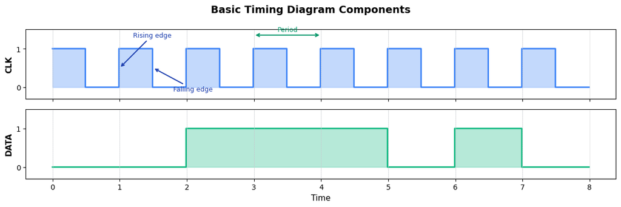

**Key elements:**

[output not shown]

## Signal Types in Timing Diagrams

Digital systems use several types of signals, each with distinct characteristics.

**Important: Inputs vs Outputs**

Timing diagrams show signals from the perspective of a specific component. Before reading any timing diagram, ask: "What component am I looking at?"

- **Inputs**: Signals coming *into* the component from external sources
- **Outputs**: Signals generated *by* the component

In the example below, imagine we're looking at a **data processing module**:

| Signal | Direction | Source |
| --- | --- | --- |
| CLK | Input | Crystal oscillator or PLL on the board |
| RST_N | Input | Power-on reset circuit (hardware that monitors power supply) |
| EN | Input | A controller or state machine that decides when this module should operate |
| D | Input | Upstream logic (e.g., a FIFO, another module's output, or external pins) |
| BUS[7:0] | Output | This module's result — downstream logic will read it |

**About the example signals:**

- **CLK**: Input from the system clock generator — every synchronous component receives this
- **RST_N (active-low reset)**: Input from the **power-on reset circuit**. The timing (0.3 to 1.8) represents:
  - **Starts at 0.3** (not exactly 0): The reset circuit needs time to detect stable power
  - **Releases at 1.8**: Released after power and clock are confirmed stable
  - This is *asynchronous* to the clock — notice it doesn't align with clock edges
- **EN (enable)**: Input from a **controller state machine** that orchestrates the system. The controller asserts EN when it wants this module to process data (cycles 2-7), then deasserts it when done.
- **D (data)**: Input from **upstream logic** — could be a sensor interface, a FIFO buffer, or another module's output. The pattern shows data arriving while the module is enabled.
- **BUS[7:0]**: Output produced by this module. The **slanting "X" lines at transitions** are standard notation meaning:
  - All 8 bits are changing simultaneously
  - The "X" pattern says "transition happening — don't sample during this time"
  - Values shown (`XX`, `00`, `01`, etc.) are the stable values between transitions
  - `XX` at startup means "unknown" — the module hasn't produced valid output yet

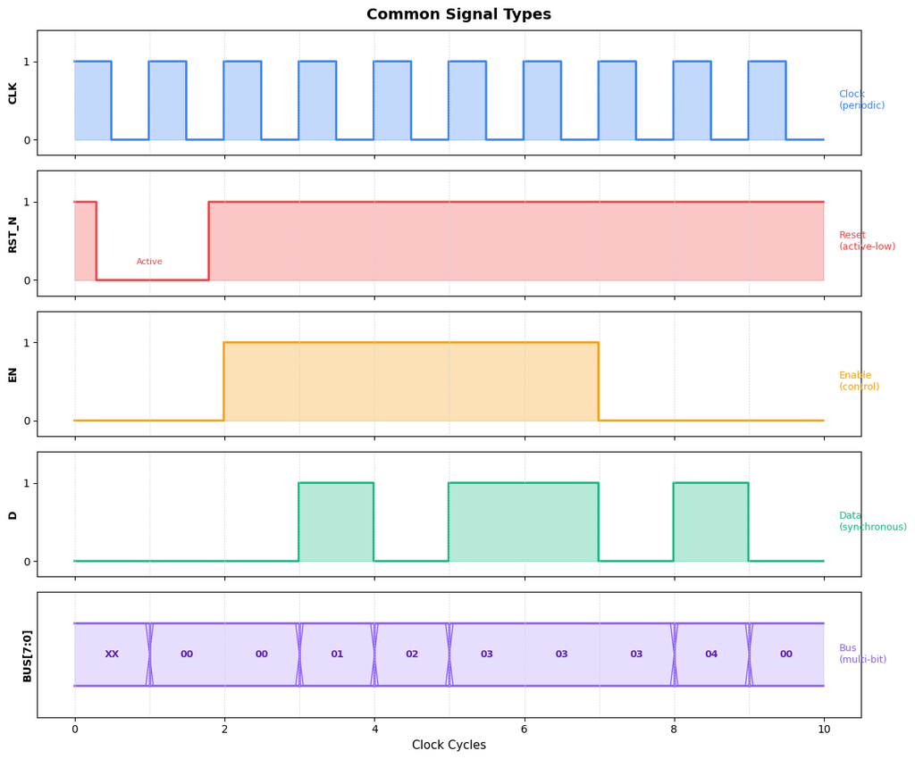

**Signal type characteristics:**

| Type | Characteristics | Examples |
| --- | --- | --- |
| **Clock** | Periodic, fixed frequency | CLK, SYSCLK |
| **Reset** | Often active-low, assertion clears state | RST_N, RESET |
| **Enable** | Gates operations on/off | EN, CE, OE |
| **Data** | Changes relative to clock | D, Q, DATA_IN |
| **Bus** | Multi-bit values shown as hex/decimal | ADDR[15:0], DATA[7:0] |

## Example: Reading a Memory Interface

Let's examine a realistic timing diagram for a simple synchronous memory read operation.

**About the signal timing:** This example models a typical synchronous SRAM read sequence:

- **CS_N (Chip Select)**: Goes low at cycle 2 and stays low through cycle 6 — the memory chip ignores all other signals when CS_N is high
- **RD_N (Read Enable)**: Asserted one cycle after CS_N (cycle 3) — this is the actual read command
- **ADDR**: Set to address `00` when CS_N goes low — we're reading from memory address 0x00
- **DATA**: Returns `42` after one cycle delay (cycle 4) — memory needs time to fetch the data
- **VALID**: Goes high when data is ready — tells the controller "you can sample now"

**Why these specific values?**

- Address `00` is simple — any address would work the same way
- Data value `42` (the "answer to everything") is memorable and clearly shows valid data vs high-impedance `ZZ`
- One-cycle latency between RD_N assertion and data valid is typical for synchronous memory
- The `ZZ` (high-impedance) shows the data bus is not being driven when no read is active

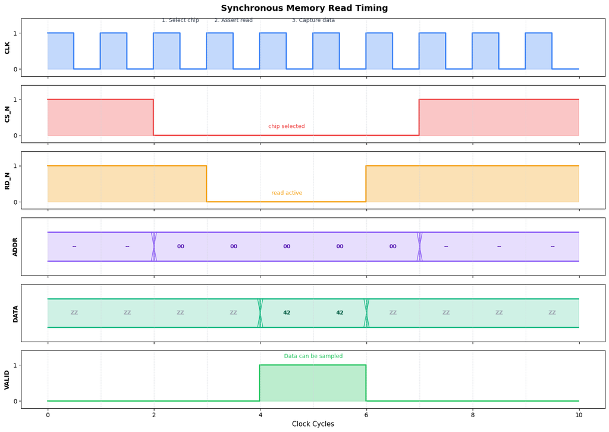

```python
import matplotlib.pyplot as plt
import numpy as np

fig, axes = plt.subplots(6, 1, figsize=(14, 10), sharex=True)
fig.suptitle('Synchronous Memory Read Timing', fontsize=14, fontweight='bold')

t = np.arange(0, 10, 0.01)

# Clock
clk = np.zeros_like(t)
for i in range(10):
    clk[(t >= i) & (t < i + 0.5)] = 1

# Chip Select (active low) - asserted at cycle 2
cs_n = np.ones_like(t)
cs_n[(t >= 2) & (t < 7)] = 0

# Read Enable (active low) - asserted at cycle 3
rd_n = np.ones_like(t)
rd_n[(t >= 3) & (t < 6)] = 0

# Address bus
addr_values = ['--', '--', '00', '00', '00', '00', '00', '--', '--', '--']

# Data bus - valid 1 cycle after read enable
data_values = ['ZZ', 'ZZ', 'ZZ', 'ZZ', '42', '42', 'ZZ', 'ZZ', 'ZZ', 'ZZ']

# Data Valid signal
valid = np.zeros_like(t)
valid[(t >= 4) & (t < 6)] = 1

# Plot clock
axes[0].fill_between(t, 0, clk, color='#3b82f6', alpha=0.3, step='pre')
axes[0].plot(t, clk, color='#3b82f6', lw=2, drawstyle='steps-pre')
axes[0].set_ylabel('CLK', fontsize=10, fontweight='bold')
axes[0].set_ylim(-0.2, 1.4)
axes[0].set_yticks([0, 1])

# Plot CS_N
axes[1].fill_between(t, 0, cs_n, color='#ef4444', alpha=0.3, step='pre')
axes[1].plot(t, cs_n, color='#ef4444', lw=2, drawstyle='steps-pre')
axes[1].set_ylabel('CS_N', fontsize=10, fontweight='bold')
axes[1].set_ylim(-0.2, 1.4)
axes[1].set_yticks([0, 1])
axes[1].text(4.5, 0.2, 'chip selected', fontsize=9, ha='center', color='#ef4444')

# Plot RD_N
axes[2].fill_between(t, 0, rd_n, color='#f59e0b', alpha=0.3, step='pre')
axes[2].plot(t, rd_n, color='#f59e0b', lw=2, drawstyle='steps-pre')
axes[2].set_ylabel('RD_N', fontsize=10, fontweight='bold')
axes[2].set_ylim(-0.2, 1.4)
axes[2].set_yticks([0, 1])
axes[2].text(4.5, 0.2, 'read active', fontsize=9, ha='center', color='#f59e0b')

# Plot Address bus
axes[3].fill_between(t, 0.2, 0.8, color='#8b5cf6', alpha=0.2)
axes[3].plot(t, np.ones_like(t) * 0.8, color='#8b5cf6', lw=2)
axes[3].plot(t, np.ones_like(t) * 0.2, color='#8b5cf6', lw=2)
for i in range(1, 10):
    if addr_values[i] != addr_values[i-1]:
        axes[3].plot([i, i], [0.2, 0.8], color='#8b5cf6', lw=2)
        axes[3].plot([i-0.05, i+0.05], [0.2, 0.8], color='#8b5cf6', lw=1)
        axes[3].plot([i-0.05, i+0.05], [0.8, 0.2], color='#8b5cf6', lw=1)
for i, val in enumerate(addr_values):
    axes[3].text(i + 0.5, 0.5, val, ha='center', va='center', fontsize=9, fontweight='bold', color='#5b21b6')
axes[3].set_ylabel('ADDR', fontsize=10, fontweight='bold')
axes[3].set_ylim(-0.1, 1.1)
axes[3].set_yticks([])

# Plot Data bus
axes[4].fill_between(t, 0.2, 0.8, color='#10b981', alpha=0.2)
axes[4].plot(t, np.ones_like(t) * 0.8, color='#10b981', lw=2)
axes[4].plot(t, np.ones_like(t) * 0.2, color='#10b981', lw=2)
for i in range(1, 10):
    if data_values[i] != data_values[i-1]:
        axes[4].plot([i, i], [0.2, 0.8], color='#10b981', lw=2)
        axes[4].plot([i-0.05, i+0.05], [0.2, 0.8], color='#10b981', lw=1)
        axes[4].plot([i-0.05, i+0.05], [0.8, 0.2], color='#10b981', lw=1)
for i, val in enumerate(data_values):
    color = '#065f46' if val not in ['ZZ', '--'] else '#9ca3af'
    axes[4].text(i + 0.5, 0.5, val, ha='center', va='center', fontsize=9, fontweight='bold', color=color)
axes[4].set_ylabel('DATA', fontsize=10, fontweight='bold')
axes[4].set_ylim(-0.1, 1.1)
axes[4].set_yticks([])

# Plot Valid
axes[5].fill_between(t, 0, valid, color='#22c55e', alpha=0.3, step='pre')
axes[5].plot(t, valid, color='#22c55e', lw=2, drawstyle='steps-pre')
axes[5].set_ylabel('VALID', fontsize=10, fontweight='bold')
axes[5].set_ylim(-0.2, 1.4)
axes[5].set_yticks([0, 1])
axes[5].set_xlabel('Clock Cycles', fontsize=11)
axes[5].text(5, 1.2, 'Data can be sampled', fontsize=9, ha='center', color='#22c55e')

# Mark clock edges
for i in range(10):
    for ax in axes:
        ax.axvline(x=i, color='#d1d5db', linestyle='--', lw=0.5)

# Annotate phases
axes[0].text(2.5, 1.3, '1. Select chip', fontsize=9, ha='center', color='#374151')
axes[0].text(3.5, 1.3, '2. Assert read', fontsize=9, ha='center', color='#374151')
axes[0].text(5, 1.3, '3. Capture data', fontsize=9, ha='center', color='#374151')

plt.tight_layout()
plt.show()
```

**Reading this timing diagram:**

1. **Cycle 2**: Address is placed on bus, chip select asserted (CS_N goes low)
2. **Cycle 3**: Read enable asserted (RD_N goes low)
3. **Cycle 4**: Memory responds with data, VALID goes high
4. **Cycles 4-5**: Data is valid — controller samples it on the rising edge
5. **Cycle 6**: Read complete, signals deasserted

**Notation conventions:**

- **ZZ**: High-impedance (tri-state, bus not driven)
- **--**: Don't care (value irrelevant)
- **_N suffix**: Active-low signal

## Common Timing Diagram Patterns

### Pattern 1: Handshaking (Request/Acknowledge)

**About the signal timing:** This pattern shows a classic "four-phase handshake":

1. **REQ asserts** (cycle 2): Requester says "I need something"
2. **ACK asserts** (cycle 4): Responder says "Got it, working on it" — the 2-cycle delay represents processing time
3. **REQ deasserts** (cycle 6): Requester sees ACK, says "Okay, I'll wait"
4. **ACK deasserts** (cycle 7): Responder finishes, ready for next request

**Why these specific timings?**

- 2-cycle delay before ACK: Shows that the responder needs time to process (could be memory access, computation, etc.)
- REQ held until ACK seen: Demonstrates proper protocol — you don't drop your request until acknowledged
- ACK held one cycle after REQ drops: Shows clean completion of the handshake

This pattern is fundamental — you'll see it in bus protocols, FIFO interfaces, and inter-module communication.

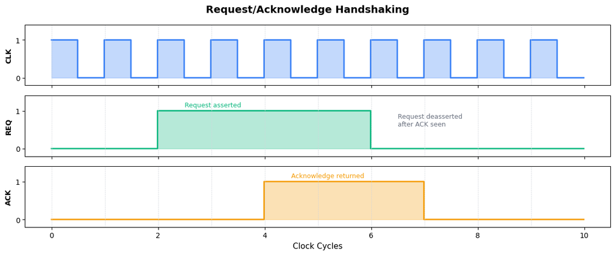

### Pattern 2: Pipeline Stages

**About the example:** We show 5 instructions (A, B, C, D, E) flowing through a 3-stage pipeline (Fetch → Decode → Execute).

**Why these specific values?**

- **3 stages**: The minimum to show pipeline behavior clearly — real CPUs have 5-20+ stages, but the principle is the same
- **5 instructions**: Enough to show:
  - Pipeline filling (cycles 1-3): Each cycle adds one more instruction in flight
  - Steady state (cycles 4-5): All 3 stages busy simultaneously
  - Pipeline draining (cycles 6-7): Last instructions completing
- **Letters A-E**: Simple labels that make it easy to track each instruction's progress through stages

This "overlap" is why pipelines improve throughput — we're doing 3 things at once instead of waiting for each instruction to fully complete.

[figure not shown]

**Pipeline insight:** At any given cycle, multiple instructions are in flight simultaneously:

- Each stage processes a different instruction
- One instruction completes per cycle (after the pipeline fills)
- Latency = 3 cycles, but throughput = 1 instruction/cycle

## Timing Hazards and Issues

### Glitches

A **glitch** is an unwanted short pulse caused by unequal propagation delays through different logic paths.

**About this example:** We use the simple logic function `Y = A AND (NOT B)` with a specific input change designed to expose the glitch:

**Why A=0→1 and B=0→1 simultaneously?**

- In the ideal world (zero delay): When both go from 0 to 1:
  - A becomes 1, B becomes 1, so NOT B becomes 0
  - Y = 1 AND 0 = 0 (no change from initial state)
- In the real world: The NOT gate has a small delay (~0.1 time units in our example)
  - A rises to 1 immediately
  - NOT B is still 1 (hasn't processed B's change yet)
  - For that brief moment: Y = 1 AND 1 = 1 → **GLITCH!**

**Why this matters:** This specific input transition (both inputs changing together) is the classic "static hazard" case. The glitch duration equals the NOT gate's propagation delay. In a real circuit, this could:

- Cause a downstream flip-flop to capture the wrong value
- Trigger unintended state machine transitions
- Corrupt data in asynchronous designs

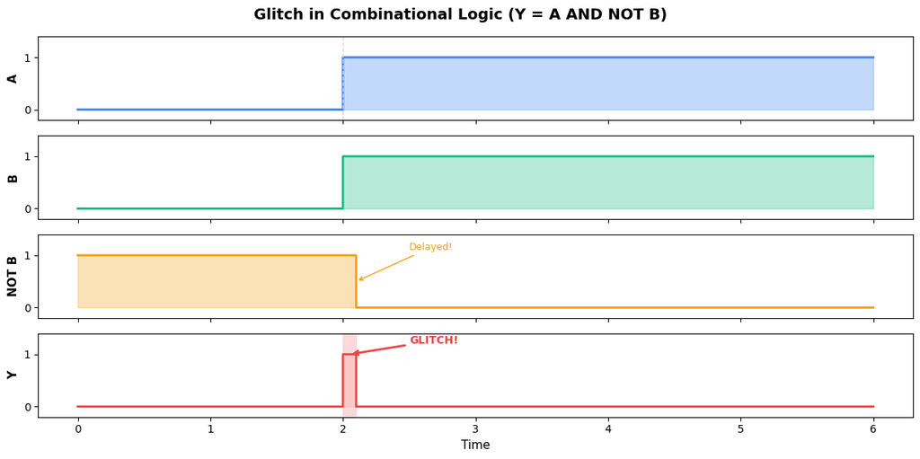

**Why glitches occur:** When A and B both change from 0→1:

- Ideally: Y stays 0 (since A·B̄ = 1·0 = 0)
- Reality: A rises immediately, but NOT B takes time to fall
- Brief moment: A=1, NOT B=1 (hasn't updated yet) → Y=1 (glitch!)

**Avoiding glitch problems:**

- Register outputs to sample only at clock edges
- Use synchronous design practices
- Add glitch filters for asynchronous inputs

## Key Takeaways

1. **Timing diagrams are essential** for understanding and debugging digital circuits
2. **Clock edges are reference points** — in synchronous design, everything happens relative to the clock
3. **Setup and hold times** define when data must be stable for reliable capture
4. **Propagation delay** limits how fast your circuit can run
5. **Common notation:**
   - Active-low signals: _N suffix or overbar
   - High-impedance: Z or Hi-Z
   - Don't care: X or --
   - Bus transitions: X-crossing pattern
6. **Practice reading timing diagrams** from datasheets — they're the universal language of digital hardware

*Timing diagrams bridge the gap between abstract logic design and physical hardware reality. Master them, and you'll be able to debug the most challenging timing issues.*